# Street gangs

CRIM 100 - WINTER 2020

## Today’s topics

- Defining gangs
- Gang correlates and theories
- Gangs in Canada

# Defining gangs

## Gang homicide?

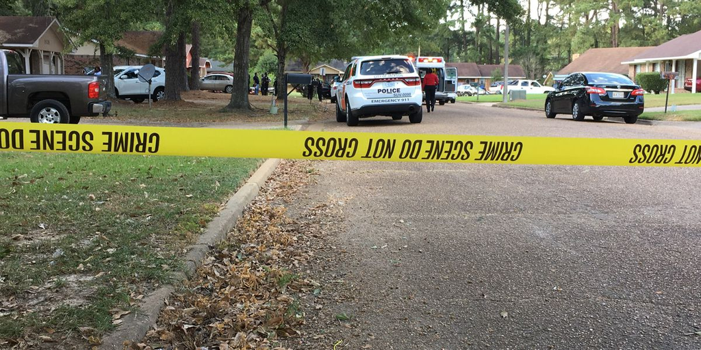

## What is a gang?

- Lack of universally accepted definition
- Definitions vary cultural and geographic context
- There are a few that are widely used (e.g., the Eurogang gang definition)

## Some examples

- Thrasher (1927)
- Klein (1971)
- Klein, Weerman and Thornberry (2006)
- Howell (2012)
- FBI (2014)

## Eurogang definition (Klein & Maxson, 2006)

“A street gang (or a troublesome youth group corresponding to a street gang elsewhere) is any durable, street-oriented youth group whose own identity includes involvement in illegal activity.”

## Static vs dynamic definitions

- Difficult to capture complexity of problem with static definitions
- Dynamic definitions overcome this limitation

## Gangs as a continuum

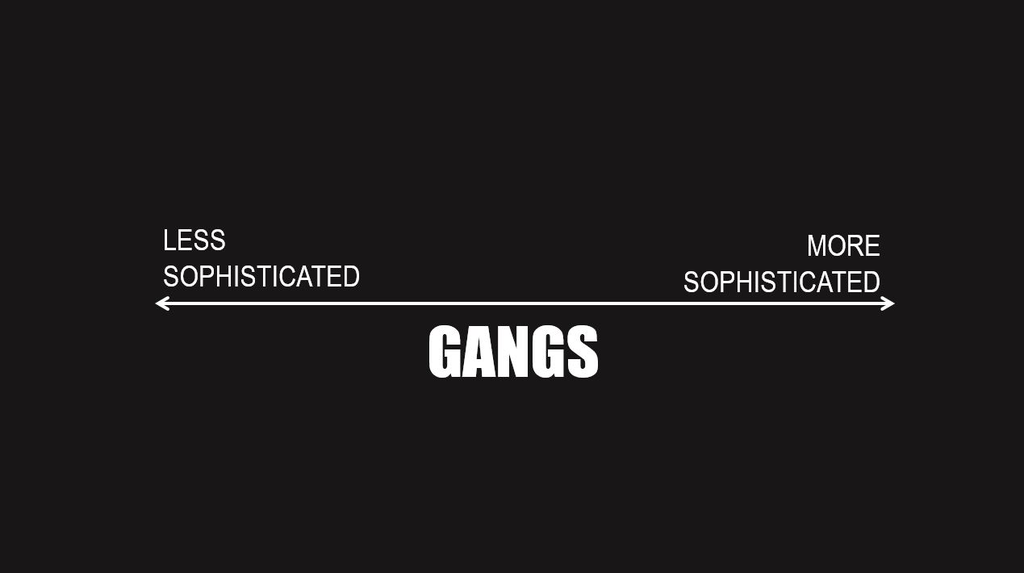

## Elements linked to gang evolution

- Response to external stimuli
- Changes in offending, organization and focus
- Know-how
- Maturity
- Leadership

## Taylor (1990) - Scavenger gangs

- Nexus based on impulsive behaviour and need to belong
- Volatile leadership
- Target the weakest actors in their neighbourhoods
- Spontaneous and unpurposive offences
- Violence perpetrated for fun
- Lack of objectives and common purpose

## Taylor (1990) - Territorial gangs

- Group identity is created
- Somebody assumes leadership position
- Territory is proclaimed, guarded and defended
- Strangers are considered invaders/enemies
- Start to organize around objectives and specific purposes
- Involvement in drugs
- Group takes advantage of authority vacuum
- Extra-legal rules set by group
- Violence is used to eliminate rivals and deal with noncompliance
- Increased mobility and expansion of territorial coverage

## Taylor (1990) - Corporate gangs

- Well defined, solid command structure
- Main purpose: illicit activities that generate monetary returns
- Memebership based what individual brings to the grpup
- Merits and not personality allows individuals to escalate hierarchy
- Task designation and specialization

## Gang membership

- Self identification
- Criteria checklist:
  - Gang peer associations
  - Criminal activity with gang members
  - Parent/guardian admission of youth’s gang involvement
  - Tattoos and/or use of gang insignia
  - Credible informant identification of a youth as a gang member

## Gang-motivated vs gang-related offences

- Chicago Police Deparment: motivation-based criteria
- Los Angeles Police Department: participant-based criteria
- Maxson & Klein (1990) found that using Chicago criteria reduced # of gang homicides in LA by aprox 50%

# Gang correlates and theories

## Historical development of gangs

- Immigration waves and inadequate conditions
- European immigrant waves in the US
- Migration of black population from rural to urban areas
- Latin american immigration wave

## Gangs in the US today

- Second generation immigrants more likely to be gang members
- Most older than 18
- 1/3 female
- Hispanics largest ethnic category in gangs
- Hybrid gangs - shift in gang membership and allegiances

## Gang evolution and correlates

- Expressive vs instrumental violence
- Planning or discussing future crimes
- Interaction with formal social control agents
- Organization and structure
- Gangs and drugs
- Gang membership
- Gang symbols and colors
- Role of prison gangs

## Main theoretical explanations

- Concentrated disadvantage
- Subcultural
- Lifecourse

## Concentrated disadvantage - Social disorganization theory

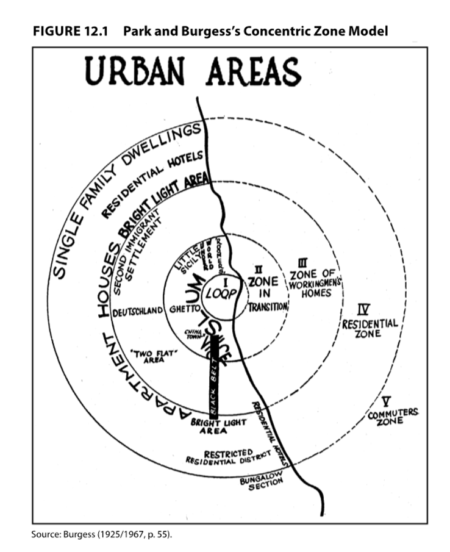

## Concentrated disadvantage - Social disorganization theory

- Shaw and McKay
- Zone II: Highest concentration offences, regardless of the ethnic group
- High crime rates did not follow ethnic groups
- Nature of neighbourhood not individuals influenced crime rates
- Breakdown in informal social control mechanisms

## Concentrated disadvantage - Social disorganization theory

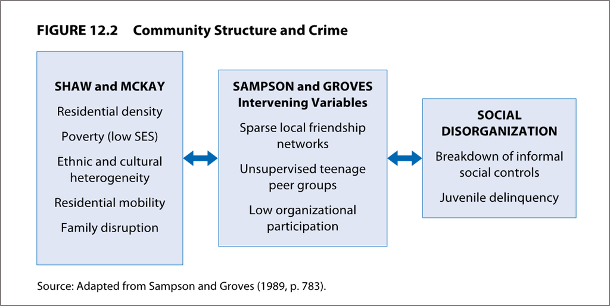

## Subcultural - Culture of The Gang (Albert Cohen)

- Cultural transmission + structurally induced strain
- Lower-class youth are disadvantaged to achieve middle-class standards of success and status
- Delinquent subculture develops when middle-class goals and norms are substituted
- Once it emerges, delinquent subculture can be transmitted
- The code of the streets (Anderson, 1999)

## Subcultural - Illegitimate opportunity theory

- Cloward & Ohlin
- Adaptation is conditioned by availability of illegitimate means
- Three types of subcultures:
- Criminal subculture in organized neighborhoods
- Conflict or fighting-oriented subculture in disorganized neighborhoods
- The retreatist or drug using subculture when double failures (unable to achieve status legitimately or illegitimately)

## Life-course - Risk and Protective factors

- Focuses on child and adolescent development
- Risk and protective factors change throughout the life course
- Serious delinquency mediates effect of risk factors
- Multiple risk factors increase likelihood of gang membership
- Accumulation of risk factors predicts gang membership

## Life-course - Multiple marginality

- Combination of macro and individual perspectives
- Discrimination and ostracism at the structural level lead to lack of economic and social opportunities, as well as to weakened social institutions(i.e., schools and families)

# Gangs in Canada

## What do we know about gangs in Canada?

- No precise measure of youth gang involvement
- Results of the 2002 Police Survey of Youth Gangs
- Provincial/local research suggests: Problem across many ethnic, geographic, demographic and socioeconomic contexts

## Populations of interest to Canadian gang scholars

- Aboriginal youth
- Immigrant youth
- Young women

## Aboriginal gangs - Hot spots

- Presence in urban, rural and correctional contexts
- Growing in prairie provinces (Winnipeg, Regina, Saskatoon and Edmonton) and northern Canada (Iqaluit and Yellowknife)

## Aboriginal gangs - Their relevance

- Concerning because aboriginal population:
  - *Growing at a relatively higher rate*
  - *Currently overrepresented in CJS*
  - *Has high victimization rate*
  - *Has high violent offending rate*

## Aboriginal gangs - Organization

- Relatively unorganized and unsophisticated
- Volatile membership
- Intergenerational

## Aboriginal gangs - Gang members

- In fringes of legitimate and illegitimate opportunity structures
- Less educated
- More economically disadvantaged
- Get involved as early as 8 years old

## Aboriginal gangs - Criminal activity

- Used by more sophisticated criminal organizations for “street work”
- Access to less profitable criminal opportunities
- Higher rates of internalized violence (compared to externalized)
- Main motivations behind gang violence: revenge, retaliation and reputation

## Aboriginal gangs - Risk factors

- Multiple marginality
  - Racism
  - Marginalization
  - Colonialization
  - loss of culture
  - loss of land
  - poverty
  - Intergenerational violence
  - Unemployment
  - Issues of poor health

## Aboriginal gangs - Risk factors

- Individual factors
  - Stressful experiences, early life hardships and negative emotions coming from marginality in other life domains
  - Involvement in delinquency
  - Early substance abuse
  - Associating with gang members
  - Weak school attachment
  - Family gang involvement
  - Poor parental monitoring
  - Parental neglect/abuse
  - Involvement in the Aboriginal child welfare system

## Gangs in BC

[video not shown]

# Content review

## Key Concepts

- Eurogang definition
- Static and dynamic gang definitions
- Gangs as a continuum
- Taylor’s gang typology (scavenger, territorial and corporate gangs)
- Gang-motivated offences
- Gang-related offences
- Social disorganization theory
- Informal social control
- The culture of the gang
- Illegitimate opportunity theory (criminal, conflict & retreatist subcultures)
- Life-course perspective (risk & protective factors)
- Multiple marginality